# Levy Replication

## Introduction

Welcome to Liam and David’s replication paper. In this segment we will be attempting, and failing badly, at replicating the results of Levy’s “Relative Strength as a Criterion for Investment Selection”. Thus far, we have attempted to replicate two of the three variables used for the analysis in the paper. In addition, there will be a literature review section where we engage in a lively conversation about similar pieces of work.

## 4/C Ratio

The 4/C Ratio is a performance ratio and is calculated by taking a stocks current weekly price average and dividing it into the stocks price four weeks into the future.

## 4/C Graph

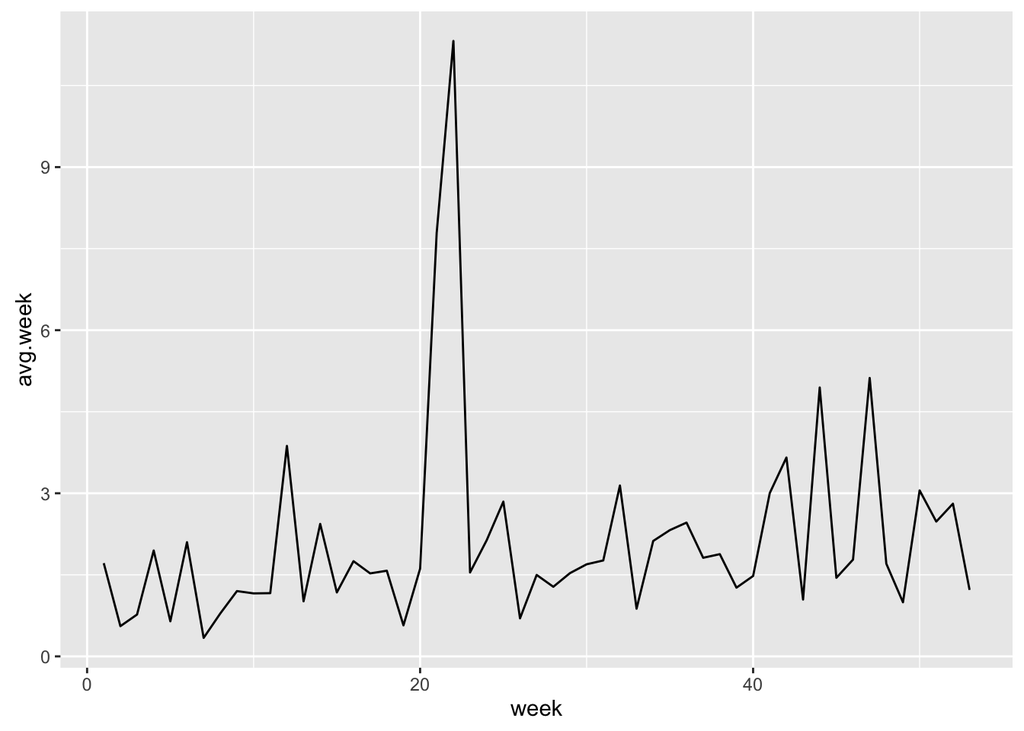

```r
weekly <- x %>% mutate(C4 = avg.price[week+4]/avg.price)
weekly %>% arrange(week) %>% summarise(avg.week = mean(C4)) %>%
    ggplot(aes(week, avg.week)) + geom_line()
```

## 26/C Ratio

The 26/C Ratio is another performance ratio and is calculated by taking a stocks current weekly price average and dividing it into the stock price 26 weeks into the future.

## 26/C graph

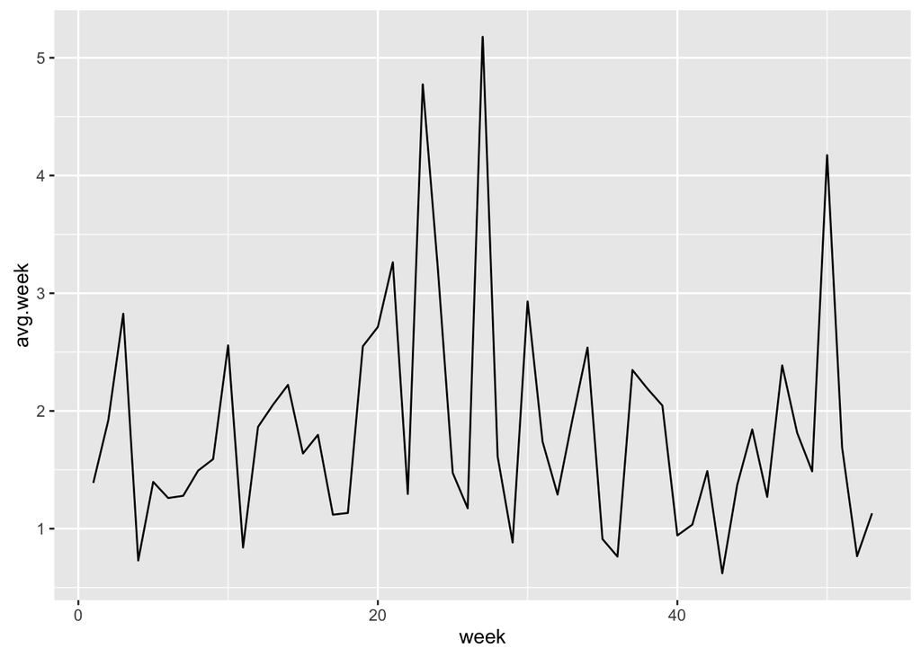

```r
weekly2 <- x %>% mutate(C26 = avg.price[week+26]/avg.price)
weekly2 %>% arrange(week) %>% summarise(avg.week = mean(C26)) %>%
    ggplot(aes(week, avg.week)) + geom_line()
```

## Literature Review

This paper analyzes relative strength as a way to decide which stocks to choose as a predictor of future returns. The idea is to choose stocks on the basis of how they have performed relative to other stocks in their selected universe on the basis of current prices, volatility, and past returns. The Levy paper is from 1967 and shows that this strategy works to provide outsized returns in 1960’s. Obviously, this takes place roughly 50 years ago, so the question is whether it still holds true. In 2010, Mebane Faber of Cambria Investments did a similar paper on relative strength titled “Relative Strength Strategies for Investing.” This paper attacks the relative strength model from a different model, where instead of investing in individual securities, they will rank sectors based on their strength and total returns. They will then invest in the top X sectors for their criteria. They find that in their time periods, relative strength not only provides strong returns, but also that it outperforms a buy and hold method of investing in 70% of years. Another paper and study that is similar to this study is “Time Series Momentum” by Moskowitz, Ooi, and Pederson. This is similar in that their analysis in done on the basis of analyzing how strong returns have been in the past as an indicator of future returns. While in the Levy paper, they see how strong prices are over the previous 26 weeks, the “Time Series Momentum” paper looks at the previous 52 weeks. They find that by analyzing the lagged 1-year returns is a strong indicator of how the next month will be for a stocks return. Comparatively, Levy shows that through the ratio of the current price and the previous 26-week period, one can rank stocks and through the formed portfolio, realize strong positive returns.